# Implementing Random Forest for regression in R from scratch.

Completing one task:

1. Implementing random forest.

#### **1. Task 1: Implementing Random Forest for regression in R from first principles.**

- You should apply your random forest program to the Boston dataset to predict `medv`.
- In other words, `medv` is **the label**, and the other 13 variables in the dataset are **the attributes**.
- Split the dataset randomly into two equal parts, which will serve as **the training set** and **the test set**.
- Use your birthday (in the format MMDD) as the seed for the pseudorandom number generator.
- The same **training set and test set** should be used throughout this assignment.

**You need to complete the following parts:**

**1.1 Introduction**

**Random forests or random decision forests** are an ensemble learning method for classification, regression and other tasks that operates by constructing a multitude of decision trees at training time.

For classification tasks, the output of the random forest is the class selected by most trees.

For regression tasks, the mean or average prediction of the individual trees is returned.

Random decision forests correct for decision trees’ habit of overfitting to their training set. Random forests generally outperform decision trees, but their accuracy is lower than gradient boosted trees. However, data characteristics can affect their performance.

**1.2. Loading the Boston data set.**

```r
library(MASS)
data(Boston)
```

```r
any(is.na(Boston))
```

```
## [1] FALSE
```

```r
dim(Boston)
```

```
## [1] 506  14
```

```r
names(Boston)
```

```
##  [1] "crim"    "zn"      "indus"   "chas"    "nox"     "rm"      "age"
##  [8] "dis"     "rad"     "tax"     "ptratio" "black"   "lstat"   "medv"
```

```r
head(Boston, 10)
```

```
##       crim   zn indus chas   nox    rm   age    dis rad tax ptratio  black
## 1  0.00632 18.0  2.31    0 0.538 6.575  65.2 4.0900   1 296    15.3 396.90
## 2  0.02731  0.0  7.07    0 0.469 6.421  78.9 4.9671   2 242    17.8 396.90
## 3  0.02729  0.0  7.07    0 0.469 7.185  61.1 4.9671   2 242    17.8 392.83
## 4  0.03237  0.0  2.18    0 0.458 6.998  45.8 6.0622   3 222    18.7 394.63
## 5  0.06905  0.0  2.18    0 0.458 7.147  54.2 6.0622   3 222    18.7 396.90
## 6  0.02985  0.0  2.18    0 0.458 6.430  58.7 6.0622   3 222    18.7 394.12
## 7  0.08829 12.5  7.87    0 0.524 6.012  66.6 5.5605   5 311    15.2 395.60
## 8  0.14455 12.5  7.87    0 0.524 6.172  96.1 5.9505   5 311    15.2 396.90
## 9  0.21124 12.5  7.87    0 0.524 5.631 100.0 6.0821   5 311    15.2 386.63
## 10 0.17004 12.5  7.87    0 0.524 6.004  85.9 6.5921   5 311    15.2 386.71
##    lstat medv
## 1   4.98 24.0
## 2   9.14 21.6
## 3   4.03 34.7
## 4   2.94 33.4
## 5   5.33 36.2
## 6   5.21 28.7
## 7  12.43 22.9
## 8  19.15 27.1
## 9  29.93 16.5
## 10 17.10 18.9
```

**1.3. Splitting the Boston data set randomly into two equal parts.**

```r
## Splitting the Boston data set.
attach(Boston)
# October, 06.
set.seed(1006)
# Splitting the Boston data set randomly into two equal parts.
data.size <- floor(nrow(Boston)*0.5)
new.data <- sample(1:nrow(Boston), size = data.size, replace=FALSE)
# The training set and the test set that will be used throughout this assignment.
boston.train <- Boston[new.data,]
boston.test <- Boston[-new.data,]
```

Separating the attributes and labels of the training set and the test set.

```r
train.X <- as.matrix(boston.train[-ncol(boston.train)])
test.X <- as.matrix(boston.test[-ncol(boston.test)])
train.Y <- as.matrix(boston.train$medv)
test.Y <- as.matrix(boston.test$medv)
```

**1.4. Random forest build-in function in R**

Applying random forest method to the Boston data set using the `randomForest` package in R.

Applying random forest program to the Boston data set to predict `medv`.

- `mtry` is the number of attributes sampled at each node.
- vntree or B is the number of decision trees to be generated.

For a regression problem with p attributes,

- we sample p/3 attributes at each node
- (if p/3 is not an integer, round up).

Sampling m=p/3 attributes at each node.

```r
#install.packages("randomForest")
library(randomForest)
p <- ncol(Boston)-1
m <- ceiling(p/3)
```

**1.5. Building a random forest of regression tree.**

```r
rf <- randomForest(medv ~ .,data = boston.train, mtry=m, ntree=100, importance=TRUE)
rf
```

```
##
## Call:
##  randomForest(formula = medv ~ ., data = boston.train, mtry = m,      ntree = 100, importance = TRUE)
##                Type of random forest: regression
##                      Number of trees: 100
## No. of variables tried at each split: 5
##
##           Mean of squared residuals: 13.98458
##                     % Var explained: 83.9
```

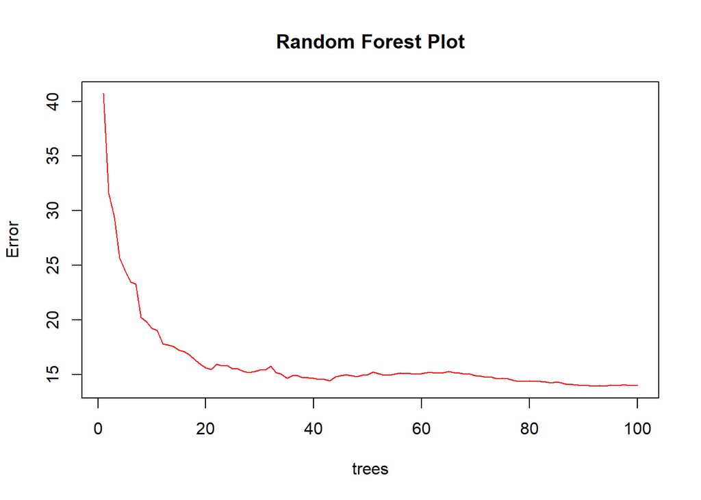

```r
plot(rf, col="red",main = "Random Forest Plot")
```

**1.6. Computing the test Mean squared error (MSE)**

```r
pred.medv <- predict(rf,test.X)
pred.medv <- round(pred.medv,1)
mse.test <- mean((pred.medv-test.Y)^2)
print(mse.test)
```

```
## [1] 11.56644
```

```r
Result <- data.frame(test.Y, pred.medv)
head(Result, 5)
```

```
##   test.Y pred.medv
## 3   34.7      37.0
## 4   33.4      33.9
## 5   36.2      32.1
## 6   28.7      26.1
## 9   16.5      18.0
```

**1.7. Computing the train Mean squared error (MSE).**

```r
yhat.medv <- predict(rf,train.X)
yhat.medv <- round(yhat.medv, 1)
mse.train <- mean((yhat.medv-train.Y)^2)
print(mse.train)
```

```
## [1] 2.804862
```

```r
Result <- data.frame(train.Y, yhat.medv)
head(Result, 5)
```

```
##     train.Y yhat.medv
## 37     20.0      20.4
## 148    14.6      15.1
## 187    50.0      46.1
## 92     22.0      22.6
## 384    12.3      11.7
```

**1.8. Next, I want to see how the number of trees affect the test MSE.**

Computing the test MSE when the numbers of trees are 10, 20, . . . , 500.

```r
test.MSE = c()
for (i in 1:50){
  rf.test.tree <- randomForest(medv~.,data=boston.train,mtry=m,ntree=i*10)
  pred.medv.test <- predict(rf.test.tree,test.X)
  print(paste("The test MSE when ntree = ", i*10, " is ",
              round(mean((pred.medv.test-test.Y)^2), 4),".", sep = ""))

  test.MSE <- c(test.MSE, round(mean((pred.medv.test-test.Y)^2), 4))
}
```

```
## [1] "The test MSE when ntree = 10 is 14.204."
## [1] "The test MSE when ntree = 20 is 13.4083."
## [1] "The test MSE when ntree = 30 is 13.8875."
## [1] "The test MSE when ntree = 40 is 12.3511."
## [1] "The test MSE when ntree = 50 is 12.7368."
## [1] "The test MSE when ntree = 60 is 11.5309."
## [1] "The test MSE when ntree = 70 is 12.3207."
## [1] "The test MSE when ntree = 80 is 12.5664."
## [1] "The test MSE when ntree = 90 is 12.3552."
## [1] "The test MSE when ntree = 100 is 11.9345."
## [1] "The test MSE when ntree = 110 is 12.6216."
## [1] "The test MSE when ntree = 120 is 12.0129."
## [1] "The test MSE when ntree = 130 is 12.0753."
## [1] "The test MSE when ntree = 140 is 11.9473."
## [1] "The test MSE when ntree = 150 is 12.1825."
```

[output cut: 35 more lines]

We can see that the test MSE did not stabilizes.

**Plotting the test MSE against ntree.**

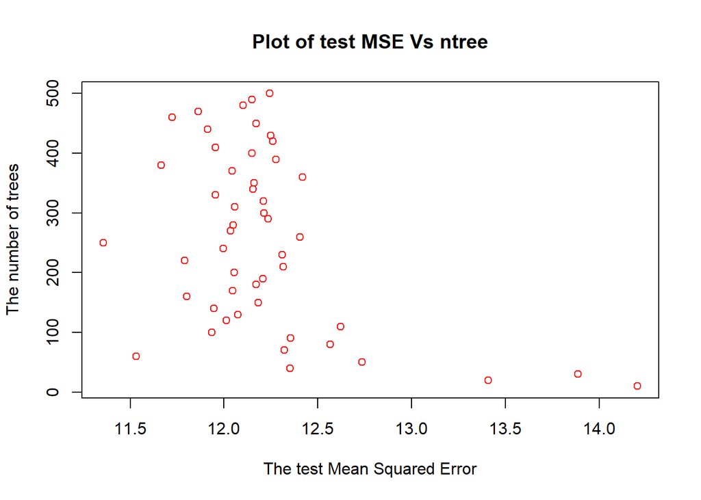

```r
# Plotting the test MSE against ntree.
ntree.seq <- seq(10,500,10)
plot(test.MSE,ntree.seq, ylab = "The number of trees",
     xlab = "The test Mean Squared Error",
     col = "red",
     main = "Plot of test MSE Vs ntree")
```

**1.9. Here, again, I want to see how the number of trees affect the train MSE.**

Computing the train MSE when the numbers of trees are 10, 20, . . . , 500.

```r
train.MSE = c()
for (i in 1:50){
  rf.train <- randomForest(medv~.,data=boston.train,mtry=m,ntree=i*10)
  pred.medv.train <- predict(rf.train,train.X)
  print(paste("The train MSE when ntree = ", i*10 , " is ",
              round(mean((pred.medv.train-train.Y)^2), 4),".", sep = ""))

  train.MSE <- c(train.MSE , round(mean((pred.medv.train-train.Y)^2), 4))
}
```

```
## [1] "The train MSE when ntree = 10 is 5.4124."
## [1] "The train MSE when ntree = 20 is 2.6828."
## [1] "The train MSE when ntree = 30 is 2.5337."
## [1] "The train MSE when ntree = 40 is 3.3317."
## [1] "The train MSE when ntree = 50 is 2.7865."
## [1] "The train MSE when ntree = 60 is 2.6068."
## [1] "The train MSE when ntree = 70 is 2.7763."
## [1] "The train MSE when ntree = 80 is 2.6758."
## [1] "The train MSE when ntree = 90 is 2.6634."
## [1] "The train MSE when ntree = 100 is 2.2208."
## [1] "The train MSE when ntree = 110 is 2.7745."
## [1] "The train MSE when ntree = 120 is 2.5663."
## [1] "The train MSE when ntree = 130 is 2.6719."
## [1] "The train MSE when ntree = 140 is 2.6754."
## [1] "The train MSE when ntree = 150 is 2.6099."
```

[output cut: 35 more lines]

We can see that the train MSE stabilizes when ntree is over 80.

**Plotting the train MSE against ntree.**

[figure not shown]

```r
plot(train.MSE,ntree.seq, ylab = "The number of trees",
     xlab = "The test Mean Squared Error",
     col = "red",
     main = "Plot of test MSE Vs ntree")
```

#### Task 1 (a).

```r
BTS <- function(data) {
    Samples <- sample(data,m, replace = TRUE)
    print(head(Samples,5))
}
BTS(boston.train)
```

```
##     medv    crim tax medv.1 zn
## 37  20.0 0.09744 279   20.0  0
## 148 14.6 2.36862 403   14.6  0
## 187 50.0 0.05602 193   50.0  0
## 92  22.0 0.03932 270   22.0  0
## 384 12.3 7.99248 666   12.3  0
```

#### Task 1 (b).

**Using each BTS to train for a decision tree of height h = 3.**

```r
setClass( "node", slots=list(is.leaf="logical", prediction="numeric", attr="character",
                             split="numeric", left.node="node", right.node="node"))
prediction <- function(node,observation){
  if (node@is.leaf){
    return(node@prediction) }
  if (observation[,node@attr] <= node@split){
    return(prediction(node@left.node, observation))
  } else {
    return(prediction(node@right.node, observation))
  }
}

# computing the average of all labels in data[indx]
avg <- function(data,indx){
  if (length(indx) == 0) {
    return(0.0)}
  d <- dim(data)[2]
  all_labels <- data[indx,d]
  return(mean(all_labels))
}

# computing the RSS of the observations in data[indx]
rss <- function(data,indx){
  if (length(indx) == 0) {
    return(0.0)}
  average <- avg(data,indx)
  d <- dim(data)[2]
  deviate <- data[indx,d] - average
  return(sum(deviate ** 2.0) )
}


optimalSplit <- function(data,indx){
  d <- dim(data)[2]
  all_attributes <- names(data)[1:(d-1)]
  opt_rss <- ((max(data[indx,d]) - min(data[indx,d])) ** 2.0 ) * length(indx) + 1.0
  for (j in all_attributes){
    # generate all possible split values
    all_cuts <- data[indx,j]
    all_cuts <- unique(all_cuts)
    for (cut in all_cuts){
      #determine which observations go to the left, and which else go to the right
      Lindx <- c()
      Rindx <- c()
      for (i in indx){
        if (data[i,j] <= cut){
          Lindx <- append(Lindx,i)
        }
        else{
          Rindx <- append(Rindx,i)
        }
      }
      #compute the total RSS, and determine if is the best split so far
      total_rss <- rss(data,Lindx) + rss(data,Rindx)
      if (total_rss < opt_rss){
        opt_rss <- total_rss
        opt_split <- list(j,cut)
      }
    }
  }
  return(opt_split)
}

generate <- function(data,indx,depth){
  node <- new("node")
  d <- dim(data)[2]
  if (depth == 0){
    node@is.leaf <- TRUE
    node@prediction <- avg(data,indx)
  }else{
    #extract all labels in data[indx], and check if they are all the same
    #if they are all the same, no split is needed, "node" is a leaf, and the prediction value is same as the common value of all the labels
    all_labels <- data[indx,d]
    all_labels <- unique(all_labels)
    if (length(all_labels) == 1){
      node@is.leaf <- TRUE
      node@prediction <- data[indx[1],d]
    }else{
      #in this case, "node" is internal, a split is needed, and we need to compute the optimal split
      node@is.leaf <- FALSE
      opt_split <- optimalSplit(data,indx)
      node@attr <- opt_split[[1]]
      node@split <- opt_split[[2]]
      #after computing the optimal split, we split data into two parts, one going to the left child, and the other going to the right child
      #we compute the indices of observations that go to left or right below
      Lindx <- c()
      Rindx <- c()
      for (i in indx){
        if (data[i,node@attr] <= node@split){
          Lindx <- append(Lindx,i)
        }
        else{
          Rindx <- append(Rindx,i)
        }
      }
      #then we create two new nodes, which are the left child and the right child of "node"
      #after this, we recursively call the function "generate" on the two children, to create one sub-tree under each child
      Lnode <- generate(data,Lindx,depth-1)
      Rnode <- generate(data,Rindx,depth-1)
      node@left.node <- Lnode
      node@right.node <- Rnode
    }
  }
  return(node)
}
```

```r
new.data.BTS <- BTS(boston.train)
```

```
##     rad chas chas.1 zn   age
## 37    5    0      0  0  61.4
## 148   5    0      0  0  95.7
## 187   3    0      0  0  53.6
## 92    2    0      0  0  73.9
## 384  24    0      0  0 100.0
```

```r
root <- generate(new.data.BTS ,1:(dim(new.data.BTS )[1]),3)
root
```

```
## An object of class "node"
## Slot "is.leaf":
## [1] FALSE
##
## Slot "prediction":
## numeric(0)
##
## Slot "attr":
## [1] "rad"
##
## Slot "split":
## [1] 5
##
## Slot "left.node":
## An object of class "node"
## Slot "is.leaf":
## [1] FALSE
##
## Slot "prediction":
## numeric(0)
##
## Slot "attr":
## [1] "rad"
##
## Slot "split":
## [1] 3
##
## Slot "left.node":
## An object of class "node"
## Slot "is.leaf":
## [1] FALSE
##
## Slot "prediction":
## numeric(0)
##
## Slot "attr":
## [1] "rad"
##
## Slot "split":
## [1] 2
```

[output cut: 106 more lines]

```
##
## Slot "prediction":
## [1] 100
##
## Slot "attr":
## character(0)
##
## Slot "split":
## numeric(0)
##
## Slot "left.node":
## NULL
##
## Slot "right.node":
## NULL
```

##### Task 1 (d).

```r
new.data.BTS.1 <- BTS(boston.train)
```

```
##        crim zn chas lstat   nox
## 37  0.09744  0    0 11.41 0.499
## 148 2.36862  0    0 29.53 0.871
## 187 0.05602  0    0  4.45 0.488
## 92  0.03932  0    0  8.20 0.489
## 384 7.99248  0    0 24.56 0.700
```

```r
root.1 <- generate(new.data.BTS.1 ,1:(dim(new.data.BTS.1)[1]),5)
root.1
```

```
## An object of class "node"
## Slot "is.leaf":
## [1] FALSE
##
## Slot "prediction":
## numeric(0)
##
## Slot "attr":
## [1] "crim"
##
## Slot "split":
## [1] 0.09744
##
## Slot "left.node":
## An object of class "node"
## Slot "is.leaf":
## [1] FALSE
##
## Slot "prediction":
## numeric(0)
##
## Slot "attr":
## [1] "crim"
##
## Slot "split":
## [1] 0.05602
##
## Slot "left.node":
## An object of class "node"
## Slot "is.leaf":
## [1] FALSE
##
## Slot "prediction":
## numeric(0)
##
## Slot "attr":
## [1] "crim"
##
## Slot "split":
## [1] 0.03932
```

[output cut: 105 more lines]

```
##
## Slot "prediction":
## [1] 0.7
##
## Slot "attr":
## character(0)
##
## Slot "split":
## numeric(0)
##
## Slot "left.node":
## NULL
##
## Slot "right.node":
## NULL
```

##### **References**

1. https://en.wikipedia.org/wiki/Random_forest